# Homework 2

Eunseo Kang

### Question 1

Your goal is to predict abalone age, which is calculated as the number of rings plus 1.5. Notice there currently is no `age` variable in the data set. Add `age` to the data set.

```r
data <- data %>%
  mutate(age=rings+1.5)
head(data)
```

```
##   type longest_shell diameter height whole_weight shucked_weight viscera_weight
## 1    M         0.455    0.365  0.095       0.5140         0.2245         0.1010
## 2    M         0.350    0.265  0.090       0.2255         0.0995         0.0485
## 3    F         0.530    0.420  0.135       0.6770         0.2565         0.1415
## 4    M         0.440    0.365  0.125       0.5160         0.2155         0.1140
## 5    I         0.330    0.255  0.080       0.2050         0.0895         0.0395
## 6    I         0.425    0.300  0.095       0.3515         0.1410         0.0775
##   shell_weight rings  age
## 1        0.150    15 16.5
## 2        0.070     7  8.5
## 3        0.210     9 10.5
## 4        0.155    10 11.5
## 5        0.055     7  8.5
## 6        0.120     8  9.5
```

Assess and describe the distribution of `age`.

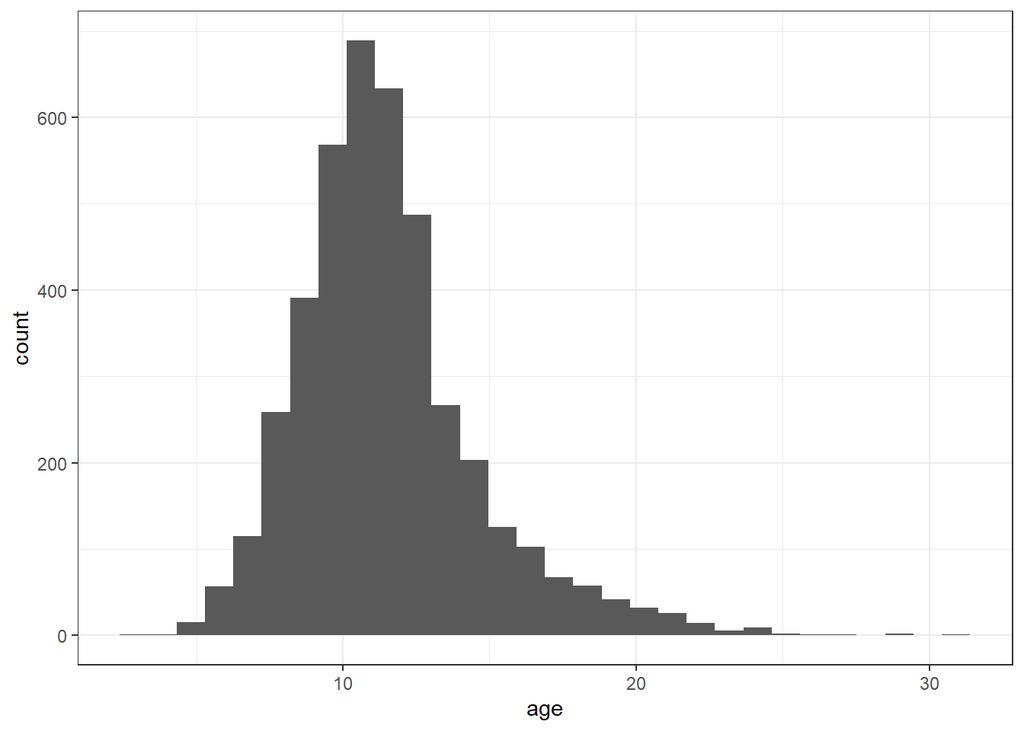

```r
data %>%
  ggplot(aes(x=age)) +
  geom_histogram() +
  theme_bw()
```

- The distribution of abalone’s age is centered around 10 and right-skewed, meaning that much of the ass of its distribution is at the lower end. Most observations range from age 5 to 20 and there are a few observations above 20.

### Question 2

Split the abalone data into a training set and a testing set. Use stratified sampling. You should decide on appropriate percentages for splitting the data.

*Remember that you’ll need to set a seed at the beginning of the document to reproduce your results.*

```r
set.seed(910514)
data_split <- initial_split(data, prop = 0.80,
                                strata = age)
data_train <- training(data_split)
data_test <- testing(data_split)
```

### Question 3

Using the **training** data, create a recipe predicting the outcome variable, `age`, with all other predictor variables. Note that you should not include `rings` to predict `age`. Explain why you shouldn’t use `rings` to predict `age`.

Steps for your recipe

1. dummy code any categorical predictors
2. create interactions between
   - `type` and `shucked_weight`,
   - `longest_shell` and `diameter`,
   - `shucked_weight` and `shell_weight`
3. center all predictors, and
4. scale all predictors.

You’ll need to investigate the `tidymodels` documentation to find the appropriate step functions to use.

```r
recipe <- recipe(age ~ ., data = data_train%>% select(-rings)) %>%
  step_dummy(all_nominal_predictors()) %>%
  step_interact(terms= ~ shucked_weight:starts_with("type")+longest_shell:diameter+shucked_weight:shell_weight) %>%
  step_normalize(all_numeric_predictors())
```

- The reason why I should not include `rings` to predict `age` is that they are perfectly correlated and including it will break the model.

### Question 4

Create and store a linear regression object using the `"lm"` engine.

```r
lm_model <- linear_reg() %>%
  set_engine("lm")
```

### Question 5

Now

1. set up an empty workflow,
2. add the model you created in Question 4, and
3. add the recipe that you created in Question 3.

```r
lm_wflow <- workflow() %>%
  add_model(lm_model) %>%
  add_recipe(recipe)
```

### Question 6

Use your `fit()` object to predict the age of a hypothetical female abalone with longest_shell = 0.50, diameter = 0.10, height = 0.30, whole_weight = 4, shucked_weight = 1, viscera_weight = 2, shell_weight = 1.

```r
lm_fit <- fit(lm_wflow, data_train%>% select(-rings))
lm_fit %>%
  # This returns the parsnip object:
  extract_fit_parsnip() %>%
  # Now tidy the linear model object:
  tidy()
```

```
## # A tibble: 14 × 5
##    term                          estimate std.error statistic  p.value
##    <chr>                            <dbl>     <dbl>     <dbl>    <dbl>
##  1 (Intercept)                     11.4      0.0373   306.    0
##  2 longest_shell                    0.386    0.281      1.37  1.70e- 1
##  3 diameter                         2.01     0.310      6.47  1.14e-10
##  4 height                           0.238    0.0704     3.37  7.50e- 4
##  5 whole_weight                     4.85     0.395     12.3   7.87e-34
##  6 shucked_weight                  -4.18     0.251    -16.6   1.03e-59
##  7 viscera_weight                  -0.916    0.155     -5.89  4.25e- 9
##  8 shell_weight                     1.63     0.215      7.61  3.60e-14
##  9 type_I                          -0.956    0.115     -8.30  1.56e-16
## 10 type_M                          -0.267    0.104     -2.57  1.03e- 2
## 11 shucked_weight_x_type_I          0.514    0.0869     5.92  3.59e- 9
## 12 shucked_weight_x_type_M          0.309    0.110      2.80  5.21e- 3
## 13 longest_shell_x_diameter        -2.53     0.397     -6.38  2.06e-10
## 14 shucked_weight_x_shell_weight   -0.194    0.202     -0.960 3.37e- 1
```

```r
#make a data to predict
new_data <- data.frame(type="F", longest_shell=0.5, diameter=0.10, height=0.30, whole_weight=4, shucked_weight=1, viscera_weight=2, shell_weight=1)
train_res <- predict(lm_fit, new_data)
head(train_res)
```

```
## # A tibble: 1 × 1
##   .pred
##   <dbl>
## 1  22.8
```

- The predicted age is 22.8154.

### Question 7

Now you want to assess your model’s performance. To do this, use the `yardstick` package:

1. Create a metric set that includes *R<sup>2</sup>*, RMSE (root mean squared error), and MAE (mean absolute error).
2. Use `predict()` and `bind_cols()` to create a tibble of your model’s predicted values from the **training data** along with the actual observed ages (these are needed to assess your model’s performance).
3. Finally, apply your metric set to the tibble, report the results, and interpret the *R<sup>2</sup>* value.

```r
#install.packages("yardstick")
metrics <- metric_set(rsq, rmse, mae)

results <- predict(lm_fit, data_train%>% select(-rings, -age))
results <- bind_cols(results, data_train %>% select(age))
head(results)
```

```
## # A tibble: 6 × 2
##   .pred   age
##   <dbl> <dbl>
## 1  9.46   8.5
## 2  8.04   8.5
## 3  9.71   8.5
## 4 10.4    8.5
## 5 10.0    9.5
## 6 10.9    9.5
```

```r
metrics(results, truth = age, estimate = .pred)
```

```
## # A tibble: 3 × 3
##   .metric .estimator .estimate
##   <chr>   <chr>          <dbl>
## 1 rsq     standard       0.558
## 2 rmse    standard       2.15
## 3 mae     standard       1.54
```

- $R^2$ is 0.56, meaning that predictors can explain 56% of the variation of ages.

### Required for 231 Students

In lecture, we presented the general bias-variance tradeoff, which takes the form:

$$E[(y_0 -
\hat{f}(x_0))^2]=Var(\hat{f}(x_0))+[Bias(\hat{f}(x_0))]^2+Var(\epsilon)$$

#### Question 8

Which term(s) in the bias-variance tradeoff above represent the reproducible error? Which term(s) represent the irreducible error?

- Terms $Var(\hat{f}(x_0))+[Bias(\hat{f}(x_0))]^2$ are the reproducible error and the term $Var(\epsilon)$ is the irreducible error.

#### Question 9

Using the bias-variance tradeoff above, demonstrate that the expected test error is always at least as large as the irreducible error.

- Since $Var(\hat{f}(x_0))=E((\hat{f}(x_0)-E(\hat{f}(x_0)))^2)\geq 0$ and $[Bias(\hat{f}(x_0))]^2 \geq 0$ because they are the squared terms,

$$Var(\hat{f}(x_0))+[Bias(\hat{f}(x_0))]^2
= E[(y_0 - \hat{f}(x_0))^2] - Var(\epsilon) \geq 0$$
$$\therefore E[(y_0 - \hat{f}(x_0))^2]\geq
Var(\epsilon)$$

#### Question 10

Prove the bias-variance tradeoff.

- $$\begin{align}
  E[(y_0 - \hat{f}(x_0))^2] & = E[(f(x_0)+\epsilon -
  \hat{f}(x_0))^2]& \\
  & = E[(f(x_0)- \hat{f}(x_0))^2]+E(\epsilon^2)+2E((f(x_0)-
  \hat{f}(x_0))\epsilon)& \\
  & = E[(f(x_0)- \hat{f}(x_0))^2]+E(\epsilon^2)+2(f(x_0)-
  \hat{f}(x_0))E(\epsilon|x) &(\text{by Law of Iterative expectation})
  \\
  & = E[(f(x_0)- \hat{f}(x_0))^2]+E(\epsilon^2) &(E(\epsilon|x)=0
  \text{since the error term and x is independent}) \\
  & = E[(f(x_0)- E(\hat{f}(x_0)) + E(\hat{f}(x_0)) - \hat{f}(x_0))^2]
  + Var(\epsilon) &\\
  & =
  E[(E(\hat{f}(x_0))-f(x_0))^2]+E[(\hat{f}(x_0)-E(\hat{f}(x_0)))^2]-2E[(f(x_0)-
  E(\hat{f}(x_0)))(E(\hat{f}(x_0)) - \hat{f}(x_0))] + Var(\epsilon)
  &\\
  & =
  (E(\hat{f}(x_0))-f(x_0))^2+E[(\hat{f}(x_0)-E(\hat{f}(x_0)))^2]-2(f(x_0)-
  E(\hat{f}(x_0)))E[(E(\hat{f}(x_0)) - \hat{f}(x_0))] + Var(\epsilon)
  & f(x_0)- E(\hat{f}(x_0)) \text{is just a constant}) \\
  & =
  (E(\hat{f}(x_0))-f(x_0))^2+E[(\hat{f}(x_0)-E(\hat{f}(x_0)))^2]-2(f(x_0)-
  E(\hat{f}(x_0)))(E(\hat{f}(x_0)) - E(\hat{f}(x_0))) + Var(\epsilon)
  & \\
  & = (E(\hat{f}(x_0))-f(x_0))^2+E[(\hat{f}(x_0)-E(\hat{f}(x_0)))^2]+
  Var(\epsilon) & \\
  & = Bias(\hat{f}(x_0))^2+Var(\hat{f}(x_0))+ Var(\epsilon)
  \end{align}$$